# Health & Lifestyle Data for Diabetes

##### How Lifestyle, Demographics, and Clinical Health Indicators Contribute to Diabetes Risk

### overview

This dataset captures detailed health, lifestyle, and clinical information from a large population of individuals, designed to analyze and predict diabetes risk. Each record represents a comprehensive profile of a patient, including demographic attributes, lifestyle behaviors, family medical background, physiological measurements, and clinical test results.

The dataset includes variables such as age, gender, ethnicity, education level, income, employment status, smoking and alcohol habits, diet and physical activity, sleep patterns, body mass index (BMI), blood pressure, cholesterol levels, glucose, insulin, HbA1c, and family or personal medical history. Most importantly, it contains target variables — diagnosed_diabetes (binary: 0 = No, 1 = Yes) and diabetes_stage (categorical: No Diabetes, Pre-Diabetes, Type 1, Type 2, Gestational) — indicating the presence and stage of diabetes.

The objective of analyzing this dataset is to uncover patterns and risk factors associated with diabetes. By examining correlations between demographic characteristics, lifestyle choices, and clinical measurements, this analysis aims to provide insights into high-risk populations, lifestyle interventions, and potential predictive indicators to support better health management and disease prevention strategies.

### Column Description

Age----> Age of the individual in years.

gender---> Biological sex of the individual (Male/Female/Other).

ethnicity---> Ethnic background of the individual.

education_level---> Highest education attained (No formal, High school, Graduate, etc.).

income_level---> Economic status categorized into income groups (Low, Medium, High).

employment_status---> Employment type or occupational status (Employed, Unemployed, Retired, Student).

smoking_status---> Smoking behavior (Never, Former, Current).

alcohol_consumption_per_week---> Average alcoholic drinks consumed per week.

physical_activity_minutes_per_week---> Minutes spent in physical activity weekly.

diet_score---> Numerical score representing dietary quality (higher = healthier).

sleep_hours_per_day---> Average number of sleeping hours per day.

screen_time_hours_per_day---> Average hours of daily screen usage.

bmi---> Body Mass Index (BMI) measured in kg/m².

waist_to_hip_ratio---> Ratio of waist circumference to hip circumference.

heart_rate---> Resting heart rate (beats per minute).

cholesterol_total---> Total cholesterol level (mg/dL).

hdl_cholesterol---> High-density lipoprotein (HDL) cholesterol (mg/dL).

ldl_cholesterol---> Low-density lipoprotein (LDL) cholesterol (mg/dL).

triglycerides---> Triglyceride level in the blood (mg/dL).

glucose_fasting---> Fasting blood glucose level (mg/dL).

glucose_postprandial---> Post-meal glucose level (mg/dL).

insulin_level---> Blood insulin concentration (µU/mL).

hba1c---> Glycated hemoglobin percentage (HbA1c %).

diabetes_risk_score---> Composite risk score estimating diabetes likelihood.

diabetes_stage---> Indicates disease stage (No Diabetes, Pre-Diabetes, Type 1, Type 2, Gestational).

diagnosed_diabetes--> Target variable showing diabetes diagnosis (0 = No, 1 = Yes)

```python
# remove the warning massage
import warnings
warnings.filterwarnings('ignore')
import pandas as pd
import numpy as np
import matplotlib.pyplot as plt
import seaborn as sns
from datetime import datetime
```

```python
df=pd.read_csv(r"C:\DataScience\Datasets\Diabetes_and_LifeStyle_Dataset .csv")
```

```python
df.head(10)
```

|  | Age | gender | ethnicity | education_level | income_level | employment_status | smoking_status | alcohol_consumption_per_week | physical_activity_minutes_per_week | diet_score | ... | hdl_cholesterol | ldl_cholesterol | triglycerides | glucose_fasting | glucose_postprandial | insulin_level | hba1c | diabetes_risk_score | diabetes_stage | diagnosed_diabetes |
| --- | --- | --- | --- | --- | --- | --- | --- | --- | --- | --- | --- | --- | --- | --- | --- | --- | --- | --- | --- | --- | --- |
| 0 | 58 | Male | Asian | Highschool | Lower-Middle | Employed | Never | 0 | 215 | 5.7 | ... | 41 | 160 | 145 | 136 | 236 | 6.36 | 8.18 | 29.6 | Type 2 | 1 |
| 1 | 52 | Female | White | Highschool | Middle | Employed | Former | 1 | 143 | 6.7 | ... | 55 | 50 | 30 | 93 | 150 | 2.00 | 5.63 | 23.0 | No Diabetes | 0 |
| 2 | 60 | Male | Hispanic | Highschool | Middle | Unemployed | Never | 1 | 57 | 6.4 | ... | 66 | 99 | 36 | 118 | 195 | 5.07 | 7.51 | 44.7 | Type 2 | 1 |
| 3 | 74 | Female | Black | Highschool | Low | Retired | Never | 0 | 49 | 3.4 | ... | 50 | 79 | 140 | 139 | 253 | 5.28 | 9.03 | 38.2 | Type 2 | 1 |
| 4 | 46 | Male | White | Graduate | Middle | Retired | Never | 1 | 109 | 7.2 | ... | 52 | 125 | 160 | 137 | 184 | 12.74 | 7.20 | 23.5 | Type 2 | 1 |
| 5 | 46 | Female | White | Highschool | Upper-Middle | Employed | Never | 2 | 124 | 9.0 | ... | 61 | 119 | 179 | 100 | 133 | 8.77 | 6.03 | 23.5 | Pre-Diabetes | 0 |
| 6 | 75 | Female | White | Graduate | Upper-Middle | Retired | Never | 0 | 53 | 9.2 | ... | 46 | 161 | 155 | 101 | 100 | 10.14 | 5.24 | 36.1 | Pre-Diabetes | 0 |
| 7 | 62 | Male | White | Postgraduate | Middle | Unemployed | Current | 1 | 75 | 4.1 | ... | 49 | 159 | 120 | 110 | 189 | 8.96 | 7.04 | 34.2 | Type 2 | 1 |
| 8 | 37 | Male | Black | Highschool | Lower-Middle | Employed | Current | 1 | 114 | 6.7 | ... | 33 | 132 | 98 | 116 | 172 | 5.70 | 6.90 | 26.7 | Type 2 | 1 |
| 9 | 59 | Female | White | Graduate | Middle | Employed | Current | 3 | 86 | 8.2 | ... | 52 | 103 | 104 | 76 | 109 | 4.49 | 4.99 | 30.0 | No Diabetes | 0 |

10 rows × 31 columns

```python
df.tail(10)
```

|  | Age | gender | ethnicity | education_level | income_level | employment_status | smoking_status | alcohol_consumption_per_week | physical_activity_minutes_per_week | diet_score | ... | hdl_cholesterol | ldl_cholesterol | triglycerides | glucose_fasting | glucose_postprandial | insulin_level | hba1c | diabetes_risk_score | diabetes_stage | diagnosed_diabetes |
| --- | --- | --- | --- | --- | --- | --- | --- | --- | --- | --- | --- | --- | --- | --- | --- | --- | --- | --- | --- | --- | --- |
| 97287 | 60 | Female | White | Highschool | Low | Retired | Never | 1 | 243 | 6.6 | ... | 52 | 90 | 109 | 117 | 175 | 8.48 | 6.84 | 23.9 | Type 2 | 1 |
| 97288 | 63 | Female | White | Highschool | Middle | Unemployed | Never | 4 | 65 | 4.0 | ... | 66 | 97 | 224 | 138 | 191 | 10.75 | 7.23 | 37.0 | Type 2 | 1 |
| 97289 | 47 | Female | White | Graduate | Middle | Employed | Never | 1 | 94 | 5.6 | ... | 48 | 140 | 163 | 125 | 157 | 8.01 | 6.94 | 29.2 | Type 2 | 1 |
| 97290 | 53 | Male | Black | Highschool | Middle | Unemployed | Current | 0 | 179 | 5.4 | ... | 47 | 109 | 97 | 129 | 161 | 4.38 | 6.69 | 25.3 | Type 2 | 1 |
| 97291 | 71 | Female | Hispanic | Graduate | Lower-Middle | Employed | Never | 1 | 82 | 6.3 | ... | 48 | 57 | 30 | 115 | 180 | 3.79 | 7.01 | 30.7 | Type 2 | 1 |
| 97292 | 46 | Male | Other | Graduate | Upper-Middle | Unemployed | Former | 1 | 136 | 8.3 | ... | 45 | 150 | 116 | 113 | 109 | 14.58 | 5.55 | 26.0 | Pre-Diabetes | 0 |
| 97293 | 41 | Female | White | Graduate | Middle | Employed | Never | 3 | 76 | 8.8 | ... | 55 | 123 | 146 | 96 | 146 | 9.02 | 5.97 | 24.4 | Pre-Diabetes | 0 |
| 97294 | 57 | Female | Black | No formal | Upper-Middle | Employed | Former | 4 | 121 | 9.9 | ... | 50 | 111 | 184 | 93 | 132 | 2.57 | 5.21 | 27.6 | No Diabetes | 0 |
| 97295 | 47 | Female | Black | Highschool | Lower-Middle | Retired | Never | 3 | 52 | 5.9 | ... | 68 | 91 | 116 | 106 | 117 | 9.81 | 5.53 | 26.4 | Pre-Diabetes | 0 |
| 97296 | 52 | Female | White | Postgraduate | Middle | Employed | Never | 1 | 248 | 2.7 | ... | 31 | 183 | 87 | 91 | 142 | 15.93 | 5.73 | 27.9 | Pre-Diabetes | 0 |

10 rows × 31 columns

```python
df = df.drop(columns=['family_history_diabetes','hypertension_history','cardiovascular_history'])
```

```python
df.dtypes
```

```
Age                                     int64
gender                                 object
ethnicity                              object
education_level                        object
income_level                           object
employment_status                      object
smoking_status                         object
alcohol_consumption_per_week            int64
physical_activity_minutes_per_week      int64
diet_score                            float64
sleep_hours_per_day                   float64
screen_time_hours_per_day             float64
bmi                                   float64
waist_to_hip_ratio                    float64
systolic_bp                             int64
diastolic_bp                            int64
heart_rate                              int64
cholesterol_total                       int64
hdl_cholesterol                         int64
ldl_cholesterol                         int64
triglycerides                           int64
glucose_fasting                         int64
glucose_postprandial                    int64
insulin_level                         float64
hba1c                                 float64
diabetes_risk_score                   float64
diabetes_stage                         object
diagnosed_diabetes                      int64
dtype: object
```

```python
df.info()
```

```
<class 'pandas.core.frame.DataFrame'>
RangeIndex: 97297 entries, 0 to 97296
Data columns (total 28 columns):
 #   Column                              Non-Null Count  Dtype
---  ------                              --------------  -----
 0   Age                                 97297 non-null  int64
 1   gender                              97297 non-null  object
 2   ethnicity                           97297 non-null  object
 3   education_level                     97297 non-null  object
 4   income_level                        97297 non-null  object
 5   employment_status                   97297 non-null  object
 6   smoking_status                      97297 non-null  object
 7   alcohol_consumption_per_week        97297 non-null  int64
 8   physical_activity_minutes_per_week  97297 non-null  int64
 9   diet_score                          97297 non-null  float64
```

[output cut: 20 more lines]

```python
print(df.isna().sum())
```

```
Age                                   0
gender                                0
ethnicity                             0
education_level                       0
income_level                          0
employment_status                     0
smoking_status                        0
alcohol_consumption_per_week          0
physical_activity_minutes_per_week    0
diet_score                            0
sleep_hours_per_day                   0
screen_time_hours_per_day             0
bmi                                   0
waist_to_hip_ratio                    0
systolic_bp                           0
diastolic_bp                          0
heart_rate                            0
cholesterol_total                     0
hdl_cholesterol                       0
ldl_cholesterol                       0
triglycerides                         0
glucose_fasting                       0
glucose_postprandial                  0
insulin_level                         0
hba1c                                 0
diabetes_risk_score                   0
diabetes_stage                        0
diagnosed_diabetes                    0
dtype: int64
```

```python
df.duplicated().sum()
```

```
0
```

```python
df.describe()
```

|  | Age | alcohol_consumption_per_week | physical_activity_minutes_per_week | diet_score | sleep_hours_per_day | screen_time_hours_per_day | bmi | waist_to_hip_ratio | systolic_bp | diastolic_bp | ... | cholesterol_total | hdl_cholesterol | ldl_cholesterol | triglycerides | glucose_fasting | glucose_postprandial | insulin_level | hba1c | diabetes_risk_score | diagnosed_diabetes |
| --- | --- | --- | --- | --- | --- | --- | --- | --- | --- | --- | --- | --- | --- | --- | --- | --- | --- | --- | --- | --- | --- |
| count | 97297.000000 | 97297.000000 | 97297.000000 | 97297.000000 | 97297.000000 | 97297.000000 | 97297.000000 | 97297.000000 | 97297.000000 | 97297.000000 | ... | 97297.000000 | 97297.000000 | 97297.000000 | 97297.000000 | 97297.000000 | 97297.000000 | 97297.000000 | 97297.000000 | 97297.000000 | 97297.000000 |
| mean | 50.192699 | 2.004543 | 118.942886 | 5.995214 | 6.997708 | 5.997031 | 25.615093 | 0.856083 | 115.800127 | 75.233964 | ... | 185.984234 | 54.043537 | 103.000308 | 121.466407 | 111.121792 | 160.014348 | 9.063591 | 6.520338 | 30.222027 | 0.600039 |
| std | 15.492557 | 1.418060 | 84.441920 | 1.780096 | 1.093726 | 2.469805 | 3.588387 | 0.046848 | 14.287977 | 8.206551 | ... | 32.013395 | 10.275047 | 33.390145 | 43.393422 | 13.590382 | 30.938915 | 4.956342 | 0.813710 | 9.065063 | 0.489892 |
| min | 19.000000 | 0.000000 | 0.000000 | 0.000000 | 3.000000 | 0.500000 | 15.000000 | 0.670000 | 90.000000 | 50.000000 | ... | 100.000000 | 20.000000 | 50.000000 | 30.000000 | 60.000000 | 70.000000 | 2.000000 | 4.000000 | 2.700000 | 0.000000 |
| 25% | 38.000000 | 1.000000 | 57.000000 | 4.800000 | 6.300000 | 4.300000 | 23.200000 | 0.820000 | 106.000000 | 70.000000 | ... | 164.000000 | 47.000000 | 78.000000 | 91.000000 | 102.000000 | 139.000000 | 5.090000 | 5.970000 | 23.800000 | 0.000000 |
| 50% | 51.000000 | 2.000000 | 100.000000 | 6.000000 | 7.000000 | 6.000000 | 25.600000 | 0.860000 | 116.000000 | 75.000000 | ... | 186.000000 | 54.000000 | 102.000000 | 121.000000 | 111.000000 | 160.000000 | 8.790000 | 6.520000 | 29.000000 | 1.000000 |
| 75% | 61.000000 | 3.000000 | 160.000000 | 7.200000 | 7.700000 | 7.700000 | 28.000000 | 0.890000 | 125.000000 | 81.000000 | ... | 208.000000 | 61.000000 | 126.000000 | 151.000000 | 120.000000 | 181.000000 | 12.450000 | 7.070000 | 35.600000 | 1.000000 |
| max | 90.000000 | 10.000000 | 833.000000 | 10.000000 | 10.000000 | 16.800000 | 39.200000 | 1.060000 | 179.000000 | 110.000000 | ... | 318.000000 | 98.000000 | 263.000000 | 344.000000 | 172.000000 | 287.000000 | 32.220000 | 9.800000 | 67.200000 | 1.000000 |

8 rows × 21 columns

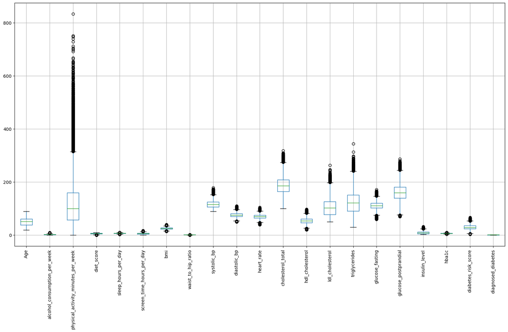

```python
# plot boxplot for checking outliers
df.boxplot(figsize=(20,10))
plt.xticks(rotation=90)
plt.show()
```

```python
numeric_cols = df.select_dtypes(include=['int64', 'float64']).columns


for col in numeric_cols:
    Q1 = df[col].quantile(0.25)
    Q3 = df[col].quantile(0.75)
    IQR = Q3 - Q1
    lower_bound = Q1 - 1.5 * IQR
    upper_bound = Q3 + 1.5 * IQR
    df = df[(df[col] >= lower_bound) & (df[col] <= upper_bound)]
```

[output not shown]

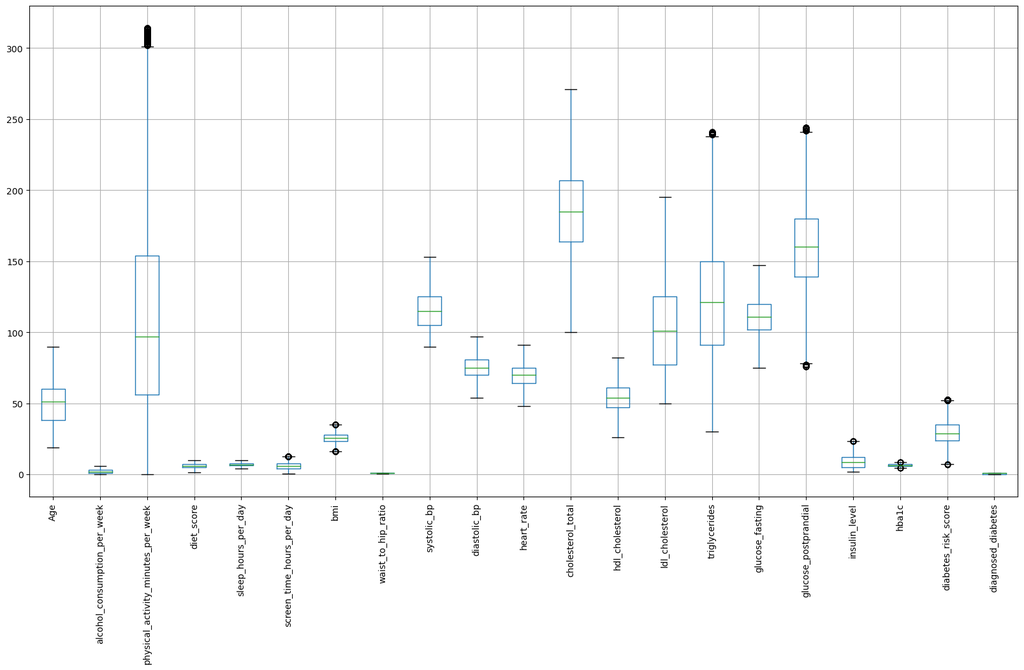

```python
# Check new shape after removing outliers
print(df.shape)



df.boxplot(figsize=(20,10))
plt.xticks(rotation=90)
plt.show()
```

EXERCISES

1. What is the age distribution of the population?

```python
df['Age'].describe()
```

```
count    85858.00000
mean        49.76835
std         15.19706
min         19.00000
25%         38.00000
50%         51.00000
75%         60.00000
max         90.00000
Name: Age, dtype: float64
```

1. Which age group has the highest diabetes prevalence?

```python
bins = [15, 24, 34, 44, 54, 64, 74, 84, 100]
labels = ['15-24','25-34','35-44','45-54','55-64','65-74','75-84','85+']

df['AgeGroup'] = pd.cut(df['Age'], bins=bins, labels=labels, right=True)

high_diabetes = df.groupby('AgeGroup')['diagnosed_diabetes'].mean().sort_values(ascending=False).reset_index()
print(high_diabetes.head(10))
```

```
  AgeGroup  diagnosed_diabetes
0      85+            0.721311
1    75-84            0.698691
2    65-74            0.682041
3    55-64            0.638869
4    45-54            0.600690
5    35-44            0.560110
6    25-34            0.525807
7    15-24            0.470674
```

Plot to show that diabetes increse with age or not?

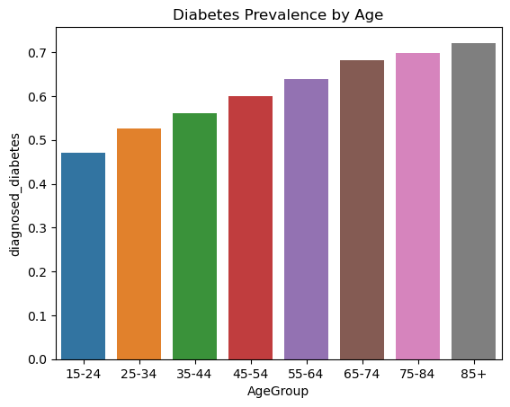

```python
sns.barplot(x='AgeGroup',y='diagnosed_diabetes',data=high_diabetes)
plt.title("Diabetes Prevalence by Age")
plt.show()
```

1. How many individuals of each gender are there?

```python
df['gender'].value_counts()
```

```
Female    43112
Male      41016
Other      1730
Name: gender, dtype: int64
```

1. which gender is most likely to affect diabetes ?

```python
gender_diabetic=df.groupby('gender')['diagnosed_diabetes'].mean().reset_index()
print(gender_diabetic)
```

```
   gender  diagnosed_diabetes
0  Female            0.597769
1    Male            0.601204
2   Other            0.615029
```

1. How does diabetes rate vary by ethnicity?

```python
df.groupby('ethnicity')['diagnosed_diabetes'].agg(['count', 'mean']).sort_values(by='count',ascending=False)
```

| ethnicity | count | mean |
| --- | --- | --- |
| White | 38613 | 0.600238 |
| Hispanic | 17258 | 0.595318 |
| Black | 15404 | 0.601272 |
| Asian | 10218 | 0.600411 |
| Other | 4365 | 0.606186 |

1. Does education level correlate with diabetes prevalence?

```python
df.groupby('education_level')['diagnosed_diabetes'].mean()
```

```
education_level
Graduate        0.600838
Highschool      0.600285
No formal       0.605874
Postgraduate    0.593570
Name: diagnosed_diabetes, dtype: float64
```

1. Does income level influence diabetes prevalence?

```python
df.groupby('income_level')['diagnosed_diabetes'].mean().sort_values(ascending=False)
```

```
income_level
High            0.606969
Lower-Middle    0.604483
Upper-Middle    0.599906
Low             0.598920
Middle          0.595613
Name: diagnosed_diabetes, dtype: float64
```

1. Is employment status related to diabetes risk?

```python
print(df.groupby('employment_status')['diagnosed_diabetes'].mean().sort_values(ascending=False))
```

```
employment_status
Unemployed    0.601409
Employed      0.601269
Student       0.597575
Retired       0.595283
Name: diagnosed_diabetes, dtype: float64
```

1. Smoking habits distribution?

```python
df['smoking_status'].value_counts()
```

```
Never      51500
Current    17185
Former     17173
Name: smoking_status, dtype: int64
```

1. Does smoking behaviour leads to diabetes or not?

```python
smoke_diabetes_rate = df.groupby('smoking_status')['diagnosed_diabetes'].mean()*100
print(smoke_diabetes_rate)
```

```
smoking_status
Current    59.877800
Former     60.193327
Never      59.935922
Name: diagnosed_diabetes, dtype: float64
```

1. Which age group shows high smoking behaviour?

```python
current_smokers = df[df['smoking_status'] == 'Current']

age_counts = current_smokers['Age'].value_counts().sort_values(ascending=False)
print(age_counts.head(10))
```

```
52    881
37    713
22    531
51    457
44    452
50    428
53    428
55    427
46    424
49    422
Name: Age, dtype: int64
```

1. gender wise smoking behaviour?

```python
df.groupby('gender')['smoking_status'].value_counts()
```

```
gender  smoking_status
Female  Never             25968
        Current            8642
        Former             8502
Male    Never             24486
        Former             8338
        Current            8192
Other   Never              1046
        Current             351
        Former              333
Name: smoking_status, dtype: int64
```

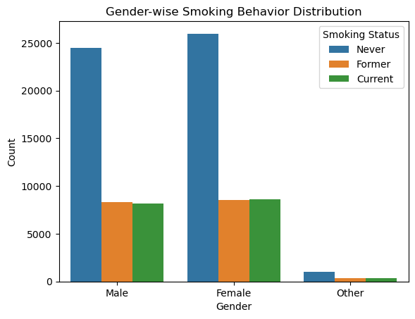

```python
sns.countplot(x='gender',data=df,hue='smoking_status')
plt.title('Gender-wise Smoking Behavior Distribution')
plt.xlabel('Gender')
plt.ylabel('Count')
plt.legend(title='Smoking Status')
plt.show()
```

1. Alcohol consumption statistics?

```python
df['alcohol_consumption_per_week'].describe()
```

```
count    85858.000000
mean         1.979466
std          1.377207
min          0.000000
25%          1.000000
50%          2.000000
75%          3.000000
max          6.000000
Name: alcohol_consumption_per_week, dtype: float64
```

1. Does alcohol consumtion is a factor for causing diabtes?

```python
alc_consumption=df.groupby('alcohol_consumption_per_week')['diagnosed_diabetes'].mean().sort_values(ascending=False).reset_index()
print(alc_consumption)
```

```
   alcohol_consumption_per_week  diagnosed_diabetes
0                             6            0.609890
1                             4            0.607786
2                             0            0.602422
3                             3            0.601652
4                             2            0.600755
5                             1            0.594410
6                             5            0.588914
```

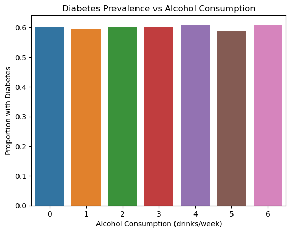

```python
sns.barplot(x='alcohol_consumption_per_week', y='diagnosed_diabetes', data=alc_consumption)
plt.title("Diabetes Prevalence vs Alcohol Consumption")
plt.xlabel("Alcohol Consumption (drinks/week)")
plt.ylabel("Proportion with Diabetes")
plt.show()
```

1. Does alcohol consumption correlate with diabetes risk?

```python
df[['alcohol_consumption_per_week','diabetes_risk_score']].corr()
```

|  | alcohol_consumption_per_week | diabetes_risk_score |
| --- | --- | --- |
| alcohol_consumption_per_week | 1.000000 | 0.010051 |
| diabetes_risk_score | 0.010051 | 1.000000 |

1. Do diabetic individuals tend to engage in less physical activity compared to non-diabetic individuals?

```python
activity= df.groupby('diagnosed_diabetes')['physical_activity_minutes_per_week'].mean().reset_index()
activity
```

|  | diagnosed_diabetes | physical_activity_minutes_per_week |
| --- | --- | --- |
| 0 | 0 | 117.508032 |
| 1 | 1 | 106.193110 |

1. What combination of lifestyle factors creates highest diabetes risk?

```python
df['multiple_risks'] = ((df['smoking_status'] == 'Current') & (df['physical_activity_minutes_per_week'] < 150) & (df['diet_score'] < df['diet_score'].median())).astype(int)
df.groupby('multiple_risks')['diagnosed_diabetes'].mean()
```

```
multiple_risks
0    0.596930
1    0.637394
Name: diagnosed_diabetes, dtype: float64
```

1. Which gender shows higher average BMI?

```python
df.groupby('gender')['bmi'].mean()
```

```
gender
Female    25.560719
Male      25.557334
Other     25.475954
Name: bmi, dtype: float64
```

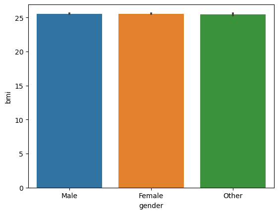

```python
sns.barplot(x='gender',y='bmi',data=df)
plt.show()
```

1. Does higher physical activity correlate with lower BMI?

```python
df[['physical_activity_minutes_per_week','bmi']].corr()
```

|  | physical_activity_minutes_per_week | bmi |
| --- | --- | --- |
| physical_activity_minutes_per_week | 1.000000 | -0.049668 |
| bmi | -0.049668 | 1.000000 |

1. Is there a relationship between diet score and BMI?

```python
df[['diet_score','bmi']].corr().iloc[0,1]
```

```
-0.18808914379917874
```

1. Do individuals with higher BMI have higher diabetes prevalence?

```python
bm=df.groupby('bmi')['diagnosed_diabetes'].mean().sort_values().reset_index()
print(bm)
```

```
      bmi  diagnosed_diabetes
0    17.7            0.379310
1    16.4            0.392857
2    17.1            0.400000
3    18.5            0.425532
4    16.2            0.428571
..    ...                 ...
188  33.6            0.764706
189  32.4            0.765101
190  34.6            0.774194
191  34.9            0.782609
192  34.8            0.785714

[193 rows x 2 columns]
```

Diabetes Prevalence by BMI Categories

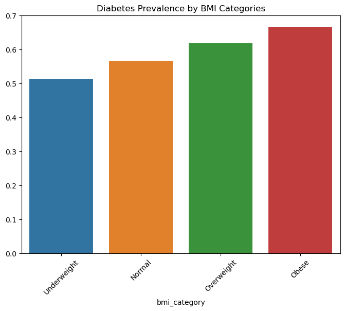

```python
plt.figure(figsize=(8,6))
df['bmi_category'] = pd.cut(df['bmi'], [0, 18.5, 25, 30, 100],labels=['Underweight', 'Normal', 'Overweight', 'Obese'])
bmi_diabetes = df.groupby('bmi_category')['diagnosed_diabetes'].mean()
sns.barplot(x=bmi_diabetes.index, y=bmi_diabetes.values)
plt.title('Diabetes Prevalence by BMI Categories')
plt.xticks(rotation=45)
plt.show()
```

1. How does waist-to-hip ratio vary across diabetes stages?

```python
df.groupby('diabetes_stage')['waist_to_hip_ratio'].mean().sort_values()
```

```
diabetes_stage
No Diabetes     0.847199
Type 1          0.847524
Gestational     0.851762
Pre-Diabetes    0.852999
Type 2          0.857881
Name: waist_to_hip_ratio, dtype: float64
```

1. Cholesterol levels (total, HDL, LDL, triglycerides): diabetic vs non-diabetic

```python
df.groupby('diagnosed_diabetes')[['cholesterol_total','hdl_cholesterol','ldl_cholesterol','triglycerides']].mean()
```

| diagnosed_diabetes | cholesterol_total | hdl_cholesterol | ldl_cholesterol | triglycerides |
| --- | --- | --- | --- | --- |
| 0 | 183.267227 | 54.642125 | 99.827581 | 118.250029 |
| 1 | 186.499689 | 53.805026 | 103.613236 | 122.399581 |

1. How does resting heart rate differ between diabetic and non-diabetic individuals?

```python
df.groupby('diagnosed_diabetes')['heart_rate'].mean()
```

```
diagnosed_diabetes
0    69.657752
1    69.925797
Name: heart_rate, dtype: float64
```

1. Which clinical measure has the strongest correlation with diabetes diagnosis?

```python
clinical_correlation=df[['glucose_fasting','bmi','hba1c','insulin_level','waist_to_hip_ratio','cholesterol_total','triglycerides','diagnosed_diabetes']].corr()

strongest_correlation=clinical_correlation['diagnosed_diabetes'].abs().sort_values()
print(strongest_correlation)
```

```
triglycerides         0.047771
insulin_level         0.047843
cholesterol_total     0.050638
waist_to_hip_ratio    0.064618
bmi                   0.081174
glucose_fasting       0.503095
hba1c                 0.684433
diagnosed_diabetes    1.000000
Name: diagnosed_diabetes, dtype: float64
```

1. How does diabetes risk score vary across different diabetes stages?

```python
db=df.groupby('diabetes_stage')['diabetes_risk_score'].mean().sort_values()
print(db)
```

```
diabetes_stage
Type 1          24.222857
No Diabetes     24.618399
Gestational     25.341803
Pre-Diabetes    28.066819
Type 2          31.901059
Name: diabetes_risk_score, dtype: float64
```

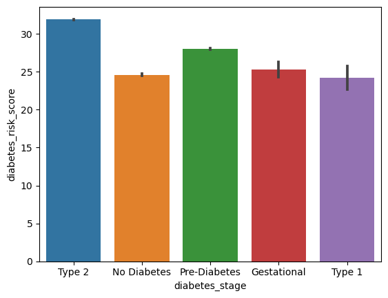

```python
sns.barplot(x='diabetes_stage',y='diabetes_risk_score',data=df)
plt.show()
```

1. What percentage of the population has diagnosed diabetes?

```python
diabetes_percentage=(df['diagnosed_diabetes'].mean()*100)
print(diabetes_percentage)
```

```
59.97577395233991
```

```python
df['diagnosed_diabetes'].value_counts()
```

```
1    51494
0    34364
Name: diagnosed_diabetes, dtype: int64
```

1. What are the average glucose and HbA1c values across different diabetes stages?

```python
df.groupby('diabetes_stage')[['glucose_fasting','hba1c']].mean().sort_values(by='glucose_fasting').reset_index()
```

|  | diabetes_stage | glucose_fasting | hba1c |
| --- | --- | --- | --- |
| 0 | No Diabetes | 91.005819 | 5.253416 |
| 1 | Pre-Diabetes | 105.830180 | 6.007676 |
| 2 | Type 1 | 106.657143 | 6.304286 |
| 3 | Gestational | 108.704918 | 6.477705 |
| 4 | Type 2 | 116.319180 | 6.948339 |

1. Histogram of Numeric Columns

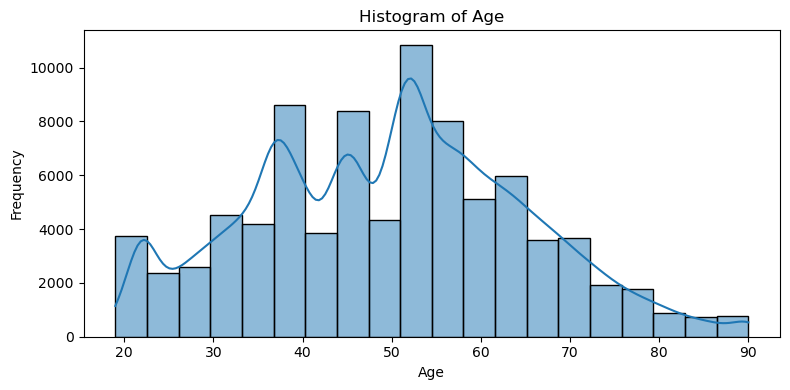

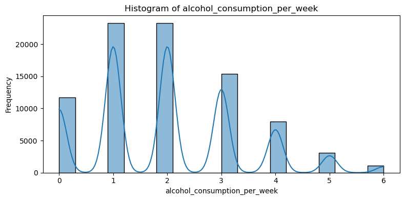

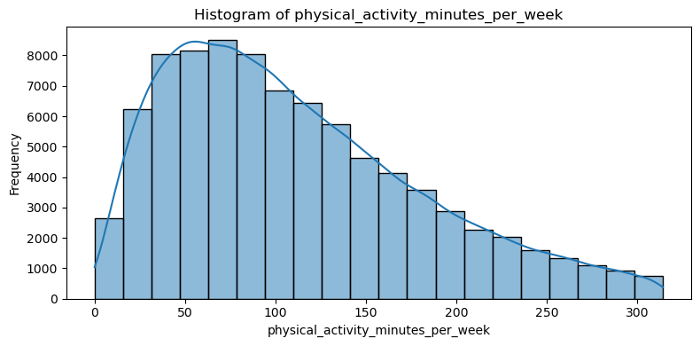

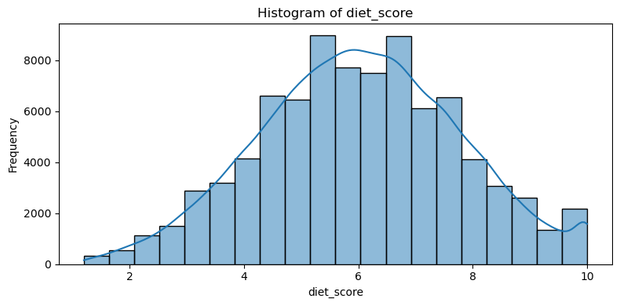

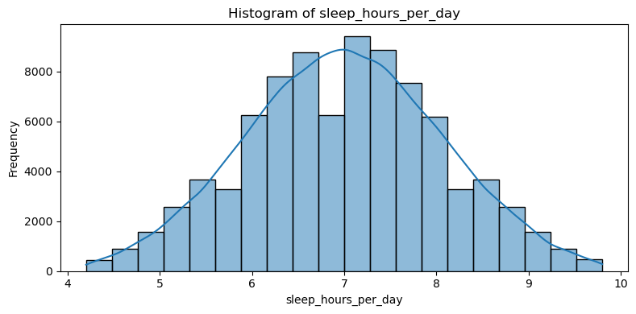

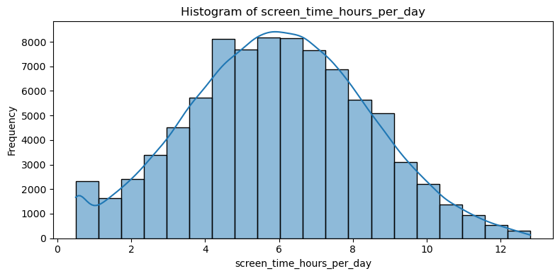

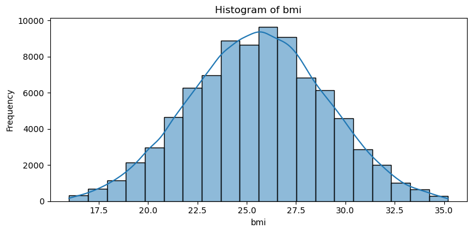

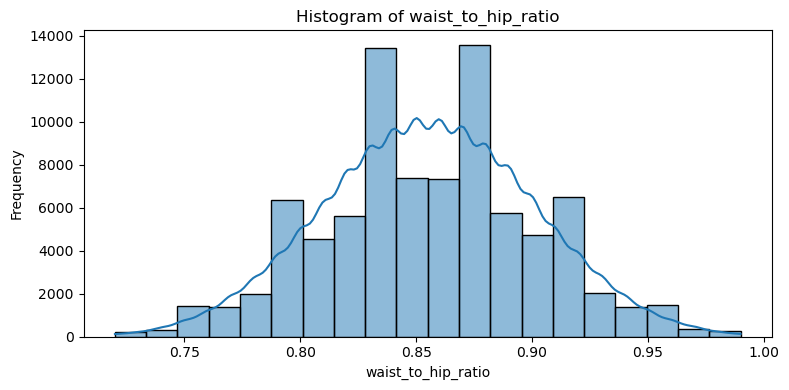

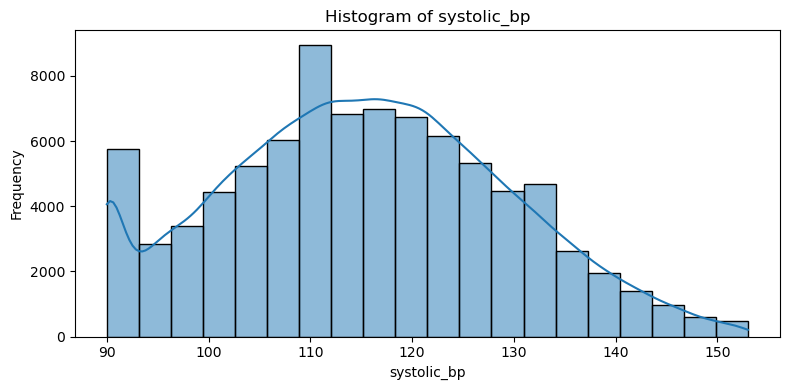

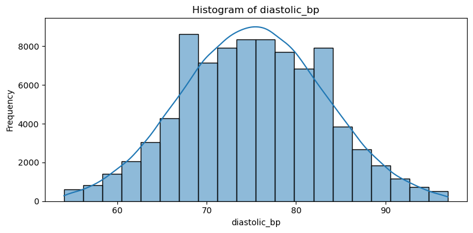

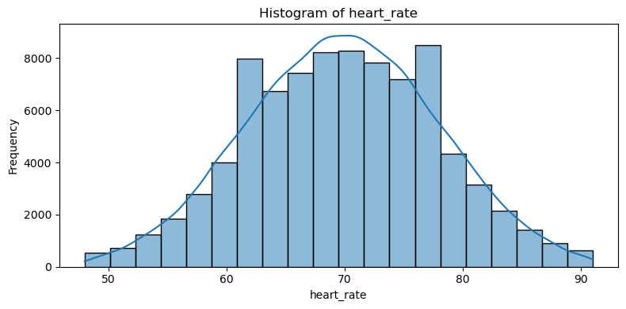

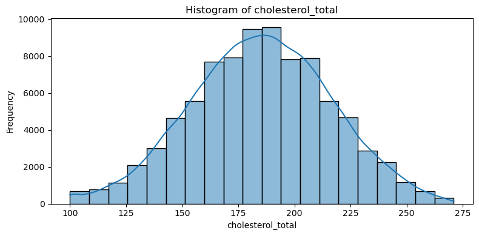

[10 more figures not shown]

```python
numerical_cols = df.select_dtypes(include='number').columns

for col in numerical_cols:

    plt.figure(figsize=(8, 4))
    sns.histplot(df[col], kde=True, bins=20)
    plt.title(f'Histogram of {col}')
    plt.xlabel(col)
    plt.ylabel('Frequency')
    plt.tight_layout()
    plt.show()
```

1. HbA1c Distribution by Diabetes Status

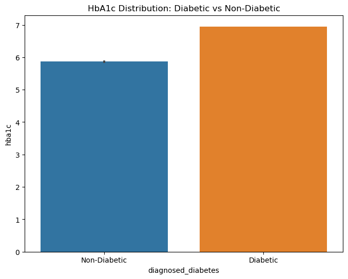

```python
plt.figure(figsize=(8,6))
sns.barplot(data=df, x='diagnosed_diabetes', y='hba1c')
plt.title('HbA1c Distribution: Diabetic vs Non-Diabetic')
plt.xticks([0, 1], ['Non-Diabetic', 'Diabetic'])
plt.show()
```

Correlation Heatmap of Key Variables

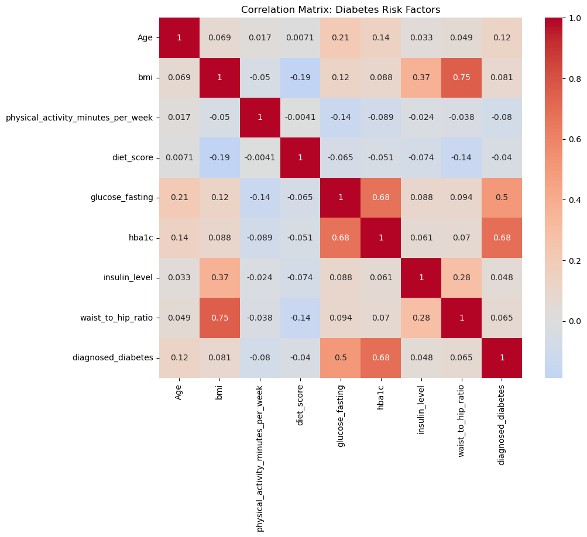

```python
plt.figure(figsize=(10,8))
key_vars = ['Age', 'bmi', 'physical_activity_minutes_per_week', 'diet_score','glucose_fasting', 'hba1c','insulin_level','waist_to_hip_ratio', 'diagnosed_diabetes']
corr_matrix = df[key_vars].corr()
sns.heatmap(corr_matrix, annot=True, cmap='coolwarm', center=0)
plt.title('Correlation Matrix: Diabetes Risk Factors')
plt.show()
```

## Conclusions & Recommendations

**1. Age is the Strongest Non-Modifiable Risk Factor**

Recommendation:

- Mandatory annual screening for all individuals over 45 years
- Develop age-specific prevention programs targeting middle-aged adults

Recommendation:

- Include waist circumference measurements in routine health check-ups
- Target abdominal fat reduction specifically in weight management programs

- Implement workplace activity programs and community exercise initiatives
- Prescribe physical activity as medical treatment for pre-diabetic patients

**4. Early Detection Through HbA1c Monitoring**

Observation: HbA1c shows strongest correlation with diabetes diagnosis among all clinical markers

Recommendation:

- Routine HbA1c testing for high-risk individuals (BMI >25, age >45)
- Establish clear intervention thresholds at pre-diabetes stage (HbA1c 5.7-6.4%)

Recommendation:

- Implement integrated lifestyle programs addressing multiple factors simultaneously
- Use risk scoring systems to identify highest-priority individuals

Recommendation:

- Develop culturally tailored education and prevention programs
- Train healthcare providers on ethnicity-specific risk factors

Recommendation:

- Focus nutrition education on food quality rather than just calorie counting
- Promote whole foods and reduce processed food consumption

**8. Systematic Screening Prevents Late Diagnosis**

Recommendation:

- Implement systematic risk-based screening in primary care settings
- Use electronic health records to flag high-risk patients automatically